# CSE 5243 - Introduction to Data Mining

## Homework 1: Exploratory Data Analysis

- Semester: Fall 2022
- Instructor: John Paparrizos / Tom Bihari
- Section: Wednesday/Friday 11:10 AM
- Student Name: John Smith
- Student Email: smith.12345@osu.edu
- Student ID: 123456789

# Introduction

This homework will focus on a modified version of the kaggle dataset "Pima Indians Diabets Database". It can be found [here](https://www.kaggle.com/uciml/pima-indians-diabetes-database). The overarching objective is to diagnostically predict whether or not a patient has diabetes based upon several other covariates. The full description is shown on the website.

Your task will be to first: 1) Do the prerequisite EDA to understand the data set you will be working on. 2) Fit an appropriate logistic model and analyze it.

While some of the questions have exact answers, a few others are more open to interpretation. However, what we're looking for is the correct thinking and analysis. For the objective questions, while some points are awarded for "the correct number", the majority of the points will be awarded for a proper analysis and logical investigation. Therefore, for each question (as appropriate) do the following:

1) Describe what you are trying to understand, determine, or answer. 2) How you are trying to do it (e.g., What are you trying to display or compute.) 3) Do it (show and run the code). 4) Describe the results and what they tell you regarding 1) above.

Note: This does not have to be lengthy. In some cases, you can say it all in a couple of sentences.

Note: The data has been modified in both some subtle and not-so-subtle ways. You're welcome to look at other previous work online (in kaggle, stack overflow, etc -- and in fact that's critical to learning how to write good code!) but be wary about just using other people's work. It would both be a violation of the academic code of conduct, but it may also lead you down the wrong path.

### Collaboration

For this assignment, you should work as an individual. You may informally discuss ideas with classmates, but your work should be your own.

### What you need to turn in:

1) Code

- For this homework, the code is the Jupyter Notebook. Use the provided Jupyter Notebook template, and fill in the appropriate information.
- You may use common Python libraries for I/O, data manipulation, data visualization, etc. (e.g., NumPy, Pandas, MatPlotLib,… See reference below.)
- You may not use library operations that perform, in effect, the “core” computations for this homework (e.g., If the assignment is to write a K-Means algorithm, you may not use a library operation that, in effect, does the core work needed to implement a K-Means algorithm.). When in doubt, ask the grader or instructor.
- The code must be written by you, and any significant code snips you found on the Internet and used to understand how to do your coding for the core functionality must be attributed. (You do not need to attribute basic functionality – matrix operations, IO, etc.)
- The code must be commented sufficiently to allow a reader to understand the algorithm without reading the actual Python, step by step.
- When in doubt, ask the grader or instructor.

2) Written Report

- For this homework, the report is the Jupyter Notebook. The report should be well-written. Please proof-read and remove spelling and grammar errors and typos.
- The report should discuss your analysis and observations. Key points and findings must be written in a style suitable for consumption by non-experts. Present charts and graphs to support your observations. If you performed any data processing, cleaning, etc., please discuss it within the report.

### Grading

1. Overall readability and organization of your report (10%)
   > - Is it well organized and does the presentation flow in a logical manner?
   > - Are there no grammar and spelling mistakes?
   > - Do the charts/graphs relate to the text?
   > - Are the summarized key points and findings understandable by non-experts?
   > - Do the Overview and Conclusions provide context for the entire exercise?
2. Domain Understanding Phase (10%)
   > - Did you provide a reasonable level of information?
3. Data Understanding Phase (30%)
   > - Did you find novel and/or interesting insights, or did you solely focus on simple summarizations of the data?
   > - Did you draw and present potential conclusion or observations from your analysis of the data?
   > - Did the statistics and visualizations you used make sense in the context of the data?
4. Data Analysis Phase (40%)
   > - Did you correctly do the data cleaning steps and perform the appropriate logistic regression.
   > - Was your analysis of the significant variables appropriate.
   > - How have you justified your feature transformation and/or feature creation steps.
5. Conclusions (10%)
   > - Did you summarize appropriately your critical findings.
   > - Did you provide appropriate conclusions and next steps.

### How to turn in your work on Carmen:

Submit to Carmen the Jupyter Notebook, the html print out of your Jupyter notebook, and any supporting files that you used to process and analyze this data. You do not need to include the input data. All submitted files (code and/or report) except for the data should be archived in a *.zip file, and submitted via Carmen. Use this naming convention:

• Project1_Surname_DotNumber.zip

The submitted file should be less than 10MB.

# Section 0: Setup

- Add any needed imports, helper functions, etc., here.

```python
import numpy as np
import pandas as pd

import matplotlib.pyplot as plt
import seaborn as sns
import sklearn as sk
import statsmodels.api as sm
import statsmodels.formula.api as smf
import os
diabetes = pd.read_csv("diabetes_hw_data_3494.csv")
diabetes
```

|  | Pregnancies | Glucose | BloodPressure | SkinThickness | Insulin | BMI | DiabetesPedigreeFunction | Age | Outcome |
| --- | --- | --- | --- | --- | --- | --- | --- | --- | --- |
| 0 | 5.0 | 144 | 82.0 | 26.0 | 285.0 | 32.0 | 0.452 | 58.0 | 1 |
| 1 | 5.0 | 137 | 108.0 | 0.0 | 0.0 | 48.8 | 0.227 | 37.0 | 1 |
| 2 | 5.0 | 109 | 75.0 | 26.0 | 0.0 | 36.0 | 0.546 | 60.0 | 0 |
| 3 | 3.0 | 113 | 50.0 | 10.0 | 85.0 | 29.5 | 0.626 | 25.0 | 0 |
| 4 | 2.0 | 96 | 68.0 | 13.0 | 49.0 | 21.1 | 0.647 | 26.0 | 0 |
| ... | ... | ... | ... | ... | ... | ... | ... | ... | ... |
| 778 | 1.0 | 71 | 48.0 | 18.0 | 76.0 | 20.4 | 0.323 | 22.0 | 0 |
| 779 | 2.0 | 112 | 78.0 | 50.0 | 140.0 | 39.4 | 0.175 | 24.0 | 0 |
| 780 | 0.0 | 138 | 0.0 | 0.0 | 0.0 | 36.3 | 0.933 | 25.0 | 1 |
| 781 | 4.0 | 183 | 0.0 | 0.0 | 0.0 | 28.4 | 0.212 | 36.0 | 1 |
| 782 | 8.0 | 183 | 448.0 | 0.0 | 0.0 | 23.3 | 0.672 | 32.0 | 1 |

783 rows × 9 columns

# Section: 1 - Domain Understanding

- Write a few paragraphs providing an overview of the data. Some questions you should consider are: Where did the data come from? What do the rows represent? Why and how was the data collected? Who might use this data? What types of questions might users be able to analyze with this data?
- You should review the dataset description information on the webpage to get some context. Of course you will only have limited background on this topic (and you are not expected to become an expert), so do your best to imagine the context for the work, making reasonable assumptions as appropriate. At this stage, you are not analyzing individual attributes, but discussing the dataset in aggregate.

The dataset was obtained from the National Institute of Diabetes and Digestive and Kidney Diseases. The purpose of the dataset is to predict whether a patient has diabetes based on existing diagnostic information. But the database has some limitations, especially since the patients in the data set were all Pima Indian women aged 21 or older.

Respectively as follows, each row of data Pregnancies - the number of pregnancy, Glucose, plasma Glucose concentration in the oral Glucose tolerance test for 2 hours, BloodPressure - diastolic blood pressure (mm Hg), SkinThickness - triceps skin thickness, the unit is mm, Insulin- 2-hour serum Insulin, BMI- body mass index, DiabetesPedigreeFunction- Diabetes spectrum function, Outcome- class variables.

I think the local government and medical center might use this data.They may want to know which variables are most associated with developing diabetes and how to deal with them.

# Section: 2 - Data Understanding

- Perform exploratory data analysis of the dataset by looking at individual attributes and/or combinations of attributes. You should focus on identifying and describing interesting observations and insights that you might uncover from the data.
- You should not simply provide the basic EDA information for all attributes in the data (although that's a good first step!). Instead, you should focus on those that are more interesting or important, and provide some discussion of what you observe. Pay particular attention to potentially interesting bivariate (two-variable) relationships, as well as the relationship between each attribute and the outcome.

## Section: 2.1 - Describe the meaning and type of data for each feature.

```python
diabetes.info()
```

```
<class 'pandas.core.frame.DataFrame'>
RangeIndex: 783 entries, 0 to 782
Data columns (total 9 columns):
 #   Column                    Non-Null Count  Dtype
---  ------                    --------------  -----
 0   Pregnancies               783 non-null    float64
 1   Glucose                   783 non-null    int64
 2   BloodPressure             783 non-null    float64
 3   SkinThickness             783 non-null    float64
 4   Insulin                   783 non-null    float64
 5   BMI                       783 non-null    float64
 6   DiabetesPedigreeFunction  783 non-null    float64
 7   Age                       783 non-null    float64
 8   Outcome                   783 non-null    int64
dtypes: float64(7), int64(2)
memory usage: 55.2 KB
```

Pregnancies is nominal.

Glucose is ratio.

BloodPressure is ratio.

Insulin is ratio.

BMI is interval.

## Section: 2.2 - Provide basic statistics for the attributes.

- For example: counts, percentiles, mean, median, standard deviation. The statistics should be relevant for the type of attribute.

```python
diabetes.mean()
```

```
Pregnancies                   3.841635
Glucose                     121.280971
BloodPressure                70.726692
SkinThickness                20.968072
Insulin                      82.762452
BMI                          32.360409
DiabetesPedigreeFunction      0.470271
Age                          34.444444
Outcome                       0.348659
dtype: float64
```

```python
diabetes.median()
```

```
Pregnancies                   3.00
Glucose                     117.00
BloodPressure                72.00
SkinThickness                23.00
Insulin                      36.00
BMI                          32.00
DiabetesPedigreeFunction      0.37
Age                          29.00
Outcome                       0.00
dtype: float64
```

```python
diabetes.std()
```

```
Pregnancies                   3.366824
Glucose                      32.325356
BloodPressure                31.374634
SkinThickness                18.732339
Insulin                     121.761453
BMI                          11.463401
DiabetesPedigreeFunction      0.330093
Age                          25.167961
Outcome                       0.476850
dtype: float64
```

```python
diabetes.quantile(q = [0, .25, .5, .75, 1])
```

|  | Pregnancies | Glucose | BloodPressure | SkinThickness | Insulin | BMI | DiabetesPedigreeFunction | Age | Outcome |
| --- | --- | --- | --- | --- | --- | --- | --- | --- | --- |
| 0.00 | 0.0 | 0.0 | 0.0 | 0.0 | 0.0 | 0.00 | 0.078 | 21.0 | 0.0 |
| 0.25 | 1.0 | 99.0 | 63.0 | 0.0 | 0.0 | 27.35 | 0.242 | 24.0 | 0.0 |
| 0.50 | 3.0 | 117.0 | 72.0 | 23.0 | 36.0 | 32.00 | 0.370 | 29.0 | 0.0 |
| 0.75 | 6.0 | 141.0 | 80.0 | 32.0 | 130.0 | 36.60 | 0.625 | 41.0 | 1.0 |
| 1.00 | 17.0 | 199.0 | 504.0 | 273.0 | 846.0 | 264.60 | 2.420 | 567.0 | 1.0 |

```python
diabetes.describe()
```

|  | Pregnancies | Glucose | BloodPressure | SkinThickness | Insulin | BMI | DiabetesPedigreeFunction | Age | Outcome |
| --- | --- | --- | --- | --- | --- | --- | --- | --- | --- |
| count | 783.000000 | 783.000000 | 783.000000 | 783.000000 | 783.000000 | 783.000000 | 783.000000 | 783.000000 | 783.000000 |
| mean | 3.841635 | 121.280971 | 70.726692 | 20.968072 | 82.762452 | 32.360409 | 0.470271 | 34.444444 | 0.348659 |
| std | 3.366824 | 32.325356 | 31.374634 | 18.732339 | 121.761453 | 11.463401 | 0.330093 | 25.167961 | 0.476850 |
| min | 0.000000 | 0.000000 | 0.000000 | 0.000000 | 0.000000 | 0.000000 | 0.078000 | 21.000000 | 0.000000 |
| 25% | 1.000000 | 99.000000 | 63.000000 | 0.000000 | 0.000000 | 27.350000 | 0.242000 | 24.000000 | 0.000000 |
| 50% | 3.000000 | 117.000000 | 72.000000 | 23.000000 | 36.000000 | 32.000000 | 0.370000 | 29.000000 | 0.000000 |
| 75% | 6.000000 | 141.000000 | 80.000000 | 32.000000 | 130.000000 | 36.600000 | 0.625000 | 41.000000 | 1.000000 |
| max | 17.000000 | 199.000000 | 504.000000 | 273.000000 | 846.000000 | 264.600000 | 2.420000 | 567.000000 | 1.000000 |

## Section: 2.3 - Visualize the most important or interesting attributes using appropriate techniques.

- For each visualization, provide an interpretation explaining why it is appropriate or interesting. What does each visualization tell us?

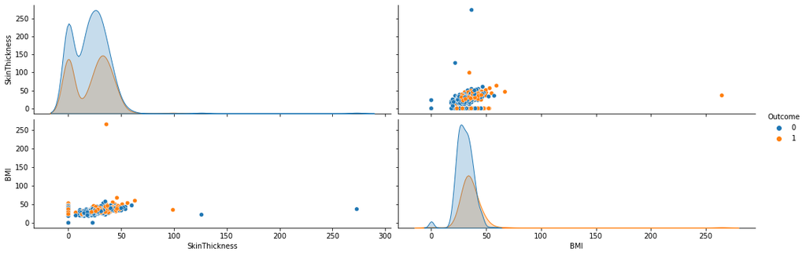

```python
sns.pairplot(diabetes, vars=['SkinThickness','BMI'],hue = 'Outcome',height = 2.5,aspect = 3)
```

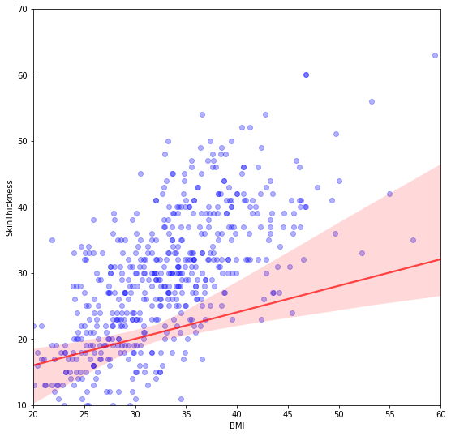

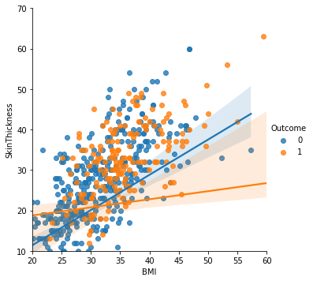

```python
plt.figure(figsize = [9,9])
sns.regplot(data = diabetes, x='BMI',y='SkinThickness',scatter_kws={'color' : 'b','alpha':0.3},line_kws = {'color':'r','alpha':0.7})
plt.ylim(10, 70)
plt.xlim(20, 60)
sns.lmplot(data = diabetes, x='BMI',y='SkinThickness',hue = 'Outcome')
plt.ylim(10, 70)
plt.xlim(20, 60)
plt.show()
```

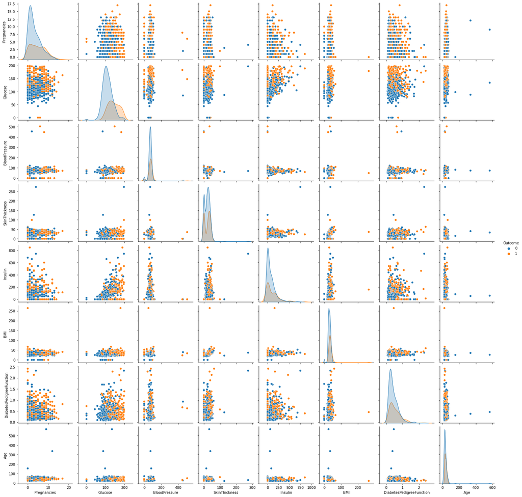

```python
sns.pairplot(diabetes, vars=diabetes.columns[:-1], hue='Outcome')
plt.show()
```

## Section: 2.4 - Verify data quality: explain any missing values, duplicate data, or outliers.

- What, if anything, do you need to do about these? Be specific.

```python
diabetes.isnull().sum()
```

```
Pregnancies                 0
Glucose                     0
BloodPressure               0
SkinThickness               0
Insulin                     0
BMI                         0
DiabetesPedigreeFunction    0
Age                         0
Outcome                     0
dtype: int64
```

As we can see the dataframe, there are no missing value.

```python
colu = ['Glucose','BloodPressure','SkinThickness','Insulin','BMI']
diabetes[colu]= diabetes[colu].replace(0,np.nan)
diabetes
```

|  | Pregnancies | Glucose | BloodPressure | SkinThickness | Insulin | BMI | DiabetesPedigreeFunction | Age | Outcome |
| --- | --- | --- | --- | --- | --- | --- | --- | --- | --- |
| 0 | 5.0 | 144.0 | 82.0 | 26.0 | 285.0 | 32.0 | 0.452 | 58.0 | 1 |
| 1 | 5.0 | 137.0 | 108.0 | NaN | NaN | 48.8 | 0.227 | 37.0 | 1 |
| 2 | 5.0 | 109.0 | 75.0 | 26.0 | NaN | 36.0 | 0.546 | 60.0 | 0 |
| 3 | 3.0 | 113.0 | 50.0 | 10.0 | 85.0 | 29.5 | 0.626 | 25.0 | 0 |
| 4 | 2.0 | 96.0 | 68.0 | 13.0 | 49.0 | 21.1 | 0.647 | 26.0 | 0 |
| ... | ... | ... | ... | ... | ... | ... | ... | ... | ... |
| 778 | 1.0 | 71.0 | 48.0 | 18.0 | 76.0 | 20.4 | 0.323 | 22.0 | 0 |
| 779 | 2.0 | 112.0 | 78.0 | 50.0 | 140.0 | 39.4 | 0.175 | 24.0 | 0 |
| 780 | 0.0 | 138.0 | NaN | NaN | NaN | 36.3 | 0.933 | 25.0 | 1 |
| 781 | 4.0 | 183.0 | NaN | NaN | NaN | 28.4 | 0.212 | 36.0 | 1 |
| 782 | 8.0 | 183.0 | 448.0 | NaN | NaN | 23.3 | 0.672 | 32.0 | 1 |

783 rows × 9 columns

In the dataframe, the Glucose,bloodPressure, skinThickness,Insulin and BMI has some 0 value. these are meaningless, so i replace as NAN.

```python
diabetes.isnull().sum()
```

```
Pregnancies                   0
Glucose                       5
BloodPressure                35
SkinThickness               232
Insulin                     380
BMI                          11
DiabetesPedigreeFunction      0
Age                           0
Outcome                       0
dtype: int64
```

```python
diabetes = diabetes.dropna()
diabetes
```

|  | Pregnancies | Glucose | BloodPressure | SkinThickness | Insulin | BMI | DiabetesPedigreeFunction | Age | Outcome |
| --- | --- | --- | --- | --- | --- | --- | --- | --- | --- |
| 0 | 5.0 | 144.0 | 82.0 | 26.0 | 285.0 | 32.0 | 0.452 | 58.0 | 1 |
| 3 | 3.0 | 113.0 | 50.0 | 10.0 | 85.0 | 29.5 | 0.626 | 25.0 | 0 |
| 4 | 2.0 | 96.0 | 68.0 | 13.0 | 49.0 | 21.1 | 0.647 | 26.0 | 0 |
| 5 | 0.0 | 105.0 | 64.0 | 41.0 | 142.0 | 41.5 | 0.173 | 22.0 | 0 |
| 6 | 0.0 | 180.0 | 78.0 | 63.0 | 14.0 | 59.4 | 2.420 | 25.0 | 1 |
| ... | ... | ... | ... | ... | ... | ... | ... | ... | ... |
| 769 | 3.0 | 80.0 | 82.0 | 31.0 | 70.0 | 34.2 | 1.292 | 27.0 | 1 |
| 771 | 0.0 | 117.0 | 66.0 | 31.0 | 188.0 | 30.8 | 0.493 | 22.0 | 0 |
| 776 | 10.0 | 125.0 | 70.0 | 26.0 | 115.0 | 31.1 | 0.205 | 41.0 | 1 |
| 778 | 1.0 | 71.0 | 48.0 | 18.0 | 76.0 | 20.4 | 0.323 | 22.0 | 0 |
| 779 | 2.0 | 112.0 | 78.0 | 50.0 | 140.0 | 39.4 | 0.175 | 24.0 | 0 |

401 rows × 9 columns

Delete a row with missing data

```python
diabetes.loc[diabetes.duplicated(),]
```

|  | Pregnancies | Glucose | BloodPressure | SkinThickness | Insulin | BMI | DiabetesPedigreeFunction | Age | Outcome |
| --- | --- | --- | --- | --- | --- | --- | --- | --- | --- |
| 226 | 11.0 | 143.0 | 94.0 | 33.0 | 146.0 | 36.6 | 0.254 | 51.0 | 1 |
| 408 | 1.0 | 193.0 | 50.0 | 16.0 | 375.0 | 25.9 | 0.655 | 24.0 | 0 |
| 416 | 4.0 | 110.0 | 76.0 | 20.0 | 100.0 | 28.4 | 0.118 | 27.0 | 0 |
| 462 | 1.0 | 121.0 | 78.0 | 39.0 | 74.0 | 39.0 | 0.261 | 28.0 | 0 |
| 521 | 0.0 | 100.0 | 88.0 | 60.0 | 110.0 | 46.8 | 0.962 | 31.0 | 0 |
| 576 | 1.0 | 193.0 | 50.0 | 16.0 | 375.0 | 25.9 | 0.655 | 24.0 | 0 |
| 607 | 1.0 | 189.0 | 60.0 | 23.0 | 846.0 | 30.1 | 0.398 | 59.0 | 1 |
| 614 | 3.0 | 84.0 | 68.0 | 30.0 | 106.0 | 31.9 | 0.591 | 25.0 | 0 |
| 728 | 5.0 | 155.0 | 84.0 | 44.0 | 545.0 | 38.7 | 0.619 | 34.0 | 0 |

There are lots of duplicate data, so I have to drop these data.

```python
diabetes = diabetes.drop_duplicates(keep = 'first')
diabetes
```

|  | Pregnancies | Glucose | BloodPressure | SkinThickness | Insulin | BMI | DiabetesPedigreeFunction | Age | Outcome |
| --- | --- | --- | --- | --- | --- | --- | --- | --- | --- |
| 0 | 5.0 | 144.0 | 82.0 | 26.0 | 285.0 | 32.0 | 0.452 | 58.0 | 1 |
| 3 | 3.0 | 113.0 | 50.0 | 10.0 | 85.0 | 29.5 | 0.626 | 25.0 | 0 |
| 4 | 2.0 | 96.0 | 68.0 | 13.0 | 49.0 | 21.1 | 0.647 | 26.0 | 0 |
| 5 | 0.0 | 105.0 | 64.0 | 41.0 | 142.0 | 41.5 | 0.173 | 22.0 | 0 |
| 6 | 0.0 | 180.0 | 78.0 | 63.0 | 14.0 | 59.4 | 2.420 | 25.0 | 1 |
| ... | ... | ... | ... | ... | ... | ... | ... | ... | ... |
| 769 | 3.0 | 80.0 | 82.0 | 31.0 | 70.0 | 34.2 | 1.292 | 27.0 | 1 |
| 771 | 0.0 | 117.0 | 66.0 | 31.0 | 188.0 | 30.8 | 0.493 | 22.0 | 0 |
| 776 | 10.0 | 125.0 | 70.0 | 26.0 | 115.0 | 31.1 | 0.205 | 41.0 | 1 |
| 778 | 1.0 | 71.0 | 48.0 | 18.0 | 76.0 | 20.4 | 0.323 | 22.0 | 0 |
| 779 | 2.0 | 112.0 | 78.0 | 50.0 | 140.0 | 39.4 | 0.175 | 24.0 | 0 |

392 rows × 9 columns

```python
diabetes.loc[diabetes.duplicated(),].sum()
```

```
Pregnancies                 0.0
Glucose                     0.0
BloodPressure               0.0
SkinThickness               0.0
Insulin                     0.0
BMI                         0.0
DiabetesPedigreeFunction    0.0
Age                         0.0
Outcome                     0.0
dtype: float64
```

Now, data is clear, all good!

```python
diabetes.quantile(0.75)+1.5*(diabetes.quantile(0.75)- diabetes.quantile(0.25))
```

```
Pregnancies                  11.000000
Glucose                     209.000000
BloodPressure               102.000000
SkinThickness                61.000000
Insulin                     362.625000
BMI                          50.150000
DiabetesPedigreeFunction      1.312875
Age                          55.500000
Outcome                       2.500000
dtype: float64
```

## Section: 2.5 - Explore the relationships among the features, excluding the outcome attribute.

- Use scatter plots, correlation matrices, cross-tabulations, group-wise averages, or other appropriate techniques. Explain and interpret any interesting relationships.

```python
diabetes.corr()
```

|  | Pregnancies | Glucose | BloodPressure | SkinThickness | Insulin | BMI | DiabetesPedigreeFunction | Age | Outcome |
| --- | --- | --- | --- | --- | --- | --- | --- | --- | --- |
| Pregnancies | 1.000000 | 0.198291 | 0.213355 | 0.068596 | 0.068213 | -0.056768 | 0.007562 | 0.324728 | 0.256566 |
| Glucose | 0.198291 | 1.000000 | 0.210027 | 0.218270 | 0.556891 | 0.185615 | 0.140180 | 0.086328 | 0.515703 |
| BloodPressure | 0.213355 | 0.210027 | 1.000000 | 0.149120 | 0.085788 | 0.086510 | -0.015971 | 0.117274 | 0.192673 |
| SkinThickness | 0.068596 | 0.218270 | 0.149120 | 1.000000 | 0.295510 | 0.248572 | 0.297504 | 0.045943 | 0.140252 |
| Insulin | 0.068213 | 0.556891 | 0.085788 | 0.295510 | 1.000000 | 0.110044 | 0.116281 | 0.007135 | 0.282104 |
| BMI | -0.056768 | 0.185615 | 0.086510 | 0.248572 | 0.110044 | 1.000000 | 0.073422 | -0.025252 | 0.199451 |
| DiabetesPedigreeFunction | 0.007562 | 0.140180 | -0.015971 | 0.297504 | 0.116281 | 0.073422 | 1.000000 | 0.003383 | 0.209330 |
| Age | 0.324728 | 0.086328 | 0.117274 | 0.045943 | 0.007135 | -0.025252 | 0.003383 | 1.000000 | 0.058655 |
| Outcome | 0.256566 | 0.515703 | 0.192673 | 0.140252 | 0.282104 | 0.199451 | 0.209330 | 0.058655 | 1.000000 |

The way I try to find out the relationships between the outcome attribute is to use correlation matrices.

Through the matrices,the most correlated attribute with Outcome is Glucose.That is easy to understand because Glucose is the only way to diagnose diabetes, and people with diabetes have high Glucose for a long time.

## Section: 2.6 - Identify and explain any interesting relationships between the outcome attribute and the other attributes.

- You may refer to earlier visualizations or create new ones. Feel free to look at $\chi^2$ values and other statsitics as you deem appropriate.

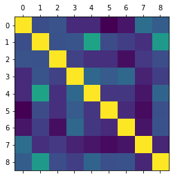

```python
plt.matshow(diabetes.corr())
```

# Section: 3 - Data Analysis

- Based on the insights gleaned in the data understanding step above, let's do some logistic regression modeling!
- One of the final outputs should be a logistic regression model and interpration of the results.

## Section: 3.1. Data Prep

- Let's assume all duplicate records are in fact false and remove them.
- Outliers can be handled in a variety of ways including removing the observation, setting them to NA's (if you're algorithm allows missing data) or imputation -- just to name a few. Let's change all the outliers to the median value of that feature WITHIN the specfic outcome group. When you compute the median, be sure to exclude the missing values.

  > Why would we want to change it to the median value as opposed to the mean?
- There's a variety of ways to handle missing data. Two of them is to either drop the entire record or impute the missing value. For this scenario we'll impute the record based upon the average value for that feature WITHIN that specific outcome group.

  > Bonus points: When you fit the logistic regression, what might this imputation operation lead to in your conclusions when analyzing the logistic regression output? Be sure to consider the case for both outliers and missing data. How can yo verify that any erroneous conclusions are discovered eventually?

### Output:

- How many duplicate records were there? Show a dataframe of which records were removed.
- How many outliers were found? Show what they were and what value they were changed to.
- Show the mean, median and std deviation of each feature after you remove duplicate records, adjust the outliers and fixed the missing values.
- Have any of the critical visualizations or relationships you discovered in section 2 changed?

```python
Q1 = np.percentile(diabetes['Pregnancies'],25, interpolation = 'midpoint')
Q3 = np.percentile(diabetes['Pregnancies'],75,interpolation = 'midpoint')
IQR = Q3 - Q1
LL = Q1 - 1.5*IQR
UL = Q3 + 1.5*IQR
outlier1 = diabetes[(diabetes['Outcome']==1)& ((diabetes['Pregnancies']>=UL)|(diabetes['Pregnancies']<=LL))]
outlier2 = diabetes[(diabetes['Outcome']==0)& ((diabetes['Pregnancies']>=UL)|(diabetes['Pregnancies']<=LL))]

print(outlier1['Pregnancies'])

print(outlier2['Pregnancies'])
```

```
39     11.0
95     12.0
117    11.0
333    11.0
364    14.0
374    15.0
410    13.0
531    12.0
547    12.0
583    11.0
633    11.0
724    17.0
Name: Pregnancies, dtype: float64
83     13.0
339    13.0
586    12.0
692    12.0
Name: Pregnancies, dtype: float64
```

```python
Q1 = np.percentile(diabetes['Glucose'],25, interpolation = 'midpoint')
Q3 = np.percentile(diabetes['Glucose'],75, interpolation = 'midpoint')
IQR = Q3 - Q1
LL = Q1 - 1.5*IQR
UL = Q3 + 1.5*IQR
outlier1 = diabetes[(diabetes['Outcome']==1)& ((diabetes['Glucose']>=UL)|(diabetes['Glucose']<=LL))]
outlier2 = diabetes[(diabetes['Outcome']==0)& ((diabetes['Glucose']>=UL)|(diabetes['Glucose']<=LL))]

print(outlier1['Glucose'])
print(outlier2['Glucose'])
```

```
Series([], Name: Glucose, dtype: float64)
Series([], Name: Glucose, dtype: float64)
```

```python
Q1 = np.percentile(diabetes['DiabetesPedigreeFunction'],25)
Q3 = np.percentile(diabetes['DiabetesPedigreeFunction'],75)
IQR = Q3 - Q1
LL = Q1 - 1.5*IQR
UL = Q3 + 1.5*IQR
outlier1 = diabetes[(diabetes['Outcome']==1)& ((diabetes['DiabetesPedigreeFunction']>=UL)|(diabetes['DiabetesPedigreeFunction']<=LL))]
outlier2 = diabetes[(diabetes['Outcome']==0)& ((diabetes['DiabetesPedigreeFunction']>=UL)|(diabetes['DiabetesPedigreeFunction']<=LL))]

print(outlier1['DiabetesPedigreeFunction'])
print(outlier2['DiabetesPedigreeFunction'])
```

```
6      2.420
14     1.391
108    1.321
152    1.390
329    2.137
333    1.353
367    1.318
725    2.288
Name: DiabetesPedigreeFunction, dtype: float64
91     2.329
229    1.400
380    1.699
482    1.600
Name: DiabetesPedigreeFunction, dtype: float64
```

## Section: 3.2 - Did you decide to implement any feature transformations? If so, why?

- If you decided you wanted to change any features, describe why and how and for what purposes. Feel free (though not required) to use mathematical notation where appropriate after providing an explanation.

NA

## Section: 3.3 - Did you decide to create any new features? If so, why?

- If you decided you wanted to create any features, describe why and how and for what purposes. Feel free (though not required) to use mathematical notation where appropriate after providing an explanation.

## Section: 3.4 - Fit a logistic regression model using the data before any transformations or additions (e.g., the data at the end of section 3.2)

- Here we want to evaluate the model. Given an interpretation and an analysis.

### Output:

- Show the model output, coefficients, p-values and other relevant statistical information.
- Provide the odds ratios of the significant parameters as well as an interpretation of that odd's ratio. Be sure to mention what level of significance you are using.
- Assuming you use a cuttoff of $\pi_i > 0.5$ when classifying diabetes what is your misclassification table.
- Assuming you use a cutoff of $\pi_i > 0.75$ when classifying diabetes what is your misclassification table.

> Bonus: Plot an ROC curve and describe it.

```python
model1 = sm.Logit(diabetes['Outcome'], sm.add_constant(diabetes[['Pregnancies','Glucose','BloodPressure','SkinThickness','Insulin','BMI','DiabetesPedigreeFunction','Age']])).fit()
print(model1.summary())
```

```
Optimization terminated successfully.
         Current function value: 0.437585
         Iterations 7
                           Logit Regression Results
==============================================================================
Dep. Variable:                Outcome   No. Observations:                  392
Model:                          Logit   Df Residuals:                      383
Method:                           MLE   Df Model:                            8
Date:                Mon, 26 Sep 2022   Pseudo R-squ.:                  0.3112
Time:                        22:14:59   Log-Likelihood:                -171.53
converged:                       True   LL-Null:                       -249.05
Covariance Type:            nonrobust   LLR p-value:                 1.747e-29
============================================================================================
                               coef    std err          z      P>|z|      [0.025      0.975]
--------------------------------------------------------------------------------------------
const                      -10.0435      1.227     -8.183      0.000     -12.449      -7.638
Pregnancies                  0.1698      0.045      3.747      0.000       0.081       0.259
Glucose                      0.0401      0.006      6.877      0.000       0.029       0.052
BloodPressure                0.0050      0.012      0.417      0.677      -0.018       0.028
SkinThickness               -0.0194      0.008     -2.305      0.021      -0.036      -0.003
Insulin                     -0.0004      0.001     -0.351      0.726      -0.003       0.002
BMI                          0.0962      0.024      4.021      0.000       0.049       0.143
DiabetesPedigreeFunction     1.4542      0.433      3.356      0.001       0.605       2.303
Age                         -0.0023      0.004     -0.522      0.601      -0.011       0.006
============================================================================================
```

```python
diabetes = pd.read_csv("diabetes_hw_data_3494.csv")
predicted_probs = model1.predict(sm.add_constant(diabetes[['Pregnancies','Glucose','BloodPressure','SkinThickness','Insulin','BMI','DiabetesPedigreeFunction','Age']]))
predicted_probs
```

```
0      0.490655
1      0.855578
2      0.303176
3      0.215373
4      0.053298
         ...
778    0.008268
779    0.134397
780    0.570377
781    0.717697
782    0.982538
Length: 783, dtype: float64
```

```python
def table(predicted_probs, labels, cutoff):
    """ Replacement for R's table funcion. """
    predicted_outcome = (predicted_probs > cutoff).astype(int)
    df = pd.DataFrame({"predicted_outcome": predicted_outcome, "actual_outcome": labels})
    return pd.crosstab(index=df["actual_outcome"], columns=df["predicted_outcome"], margins=False)

pred_table = table(predicted_probs,diabetes["Outcome"], cutoff=0.5)
pred_table
```

| predicted_outcome actual_outcome | 0 | 1 |
| --- | --- | --- |
| 0 | 445 | 65 |
| 1 | 116 | 157 |

```python
result = sm.stats.Table2x2(pred_table)
result.oddsratio
```

```
9.265915119363395
```

```python
model1 = sm.Logit(diabetes['Outcome'], sm.add_constant(diabetes[['Pregnancies','Glucose','BloodPressure','SkinThickness','Insulin','BMI','DiabetesPedigreeFunction','Age']])).fit()
print(model1.summary())
```

```
Optimization terminated successfully.
         Current function value: 0.471824
         Iterations 7
                           Logit Regression Results
==============================================================================
Dep. Variable:                Outcome   No. Observations:                  783
Model:                          Logit   Df Residuals:                      774
Method:                           MLE   Df Model:                            8
Date:                Mon, 26 Sep 2022   Pseudo R-squ.:                  0.2703
Time:                        22:14:59   Log-Likelihood:                -369.44
converged:                       True   LL-Null:                       -506.30
Covariance Type:            nonrobust   LLR p-value:                 1.596e-54
============================================================================================
                               coef    std err          z      P>|z|      [0.025      0.975]
--------------------------------------------------------------------------------------------
const                       -8.5611      0.688    -12.450      0.000      -9.909      -7.213
Pregnancies                  0.1486      0.029      5.163      0.000       0.092       0.205
Glucose                      0.0351      0.004      9.899      0.000       0.028       0.042
BloodPressure               -0.0022      0.003     -0.804      0.421      -0.008       0.003
SkinThickness               -0.0102      0.006     -1.805      0.071      -0.021       0.001
Insulin                     -0.0009      0.001     -1.068      0.286      -0.003       0.001
BMI                          0.0901      0.015      6.145      0.000       0.061       0.119
DiabetesPedigreeFunction     1.0197      0.297      3.434      0.001       0.438       1.602
Age                         -0.0017      0.004     -0.454      0.650      -0.009       0.006
============================================================================================
```

```python
predicted_probs = model1.predict(sm.add_constant(diabetes[['Pregnancies','Glucose','BloodPressure','SkinThickness','Insulin','BMI','DiabetesPedigreeFunction','Age']]))
predicted_probs
```

```
0      0.445190
1      0.788464
2      0.326009
3      0.234177
4      0.062610
         ...
778    0.015534
779    0.189228
780    0.613391
781    0.762892
782    0.685853
Length: 783, dtype: float64
```

```python
def table(predicted_probs, labels, cutoff):
    """ Replacement for R's table funcion. """
    predicted_outcome = (predicted_probs > cutoff).astype(int)
    df = pd.DataFrame({"predicted_outcome": predicted_outcome, "actual_outcome": labels})
    return pd.crosstab(index=df["actual_outcome"], columns=df["predicted_outcome"], margins=False)

pred_table = table(predicted_probs,diabetes["Outcome"], cutoff=0.75)
pred_table
```

| predicted_outcome actual_outcome | 0 | 1 |
| --- | --- | --- |
| 0 | 492 | 18 |
| 1 | 193 | 80 |

```python
result = sm.stats.Table2x2(pred_table)
result.oddsratio
```

```
11.329879101899827
```

- Here we want to see if you were able to discover features that led to an improve moodel

### Output:

- Show the model output, coefficients, p-values and other relevant statistical information.
- Provide the odds ratios of the significant parameters as well as an interpretation of that odd's ratio. Be sure to mention what level of significance you are using.
- Assuming you use a cuttoff of $\pi_i > 0.5$ when classifying diabetes what is your misclassification table.
- Assuming you use a cutoff of $\pi_i > 0.75$ when classifying diabetes what is your misclassification table.

> Bonus: Plot an ROC curve and describe it.

```python
model1 = sm.Logit(diabetes['Outcome'], sm.add_constant(diabetes[['Pregnancies','Glucose','BloodPressure','SkinThickness','Insulin','BMI','DiabetesPedigreeFunction','Age']])).fit()
print(model1.summary())
```

```
Optimization terminated successfully.
         Current function value: 0.471824
         Iterations 7
                           Logit Regression Results
==============================================================================
Dep. Variable:                Outcome   No. Observations:                  783
Model:                          Logit   Df Residuals:                      774
Method:                           MLE   Df Model:                            8
Date:                Mon, 26 Sep 2022   Pseudo R-squ.:                  0.2703
Time:                        22:14:59   Log-Likelihood:                -369.44
converged:                       True   LL-Null:                       -506.30
Covariance Type:            nonrobust   LLR p-value:                 1.596e-54
============================================================================================
                               coef    std err          z      P>|z|      [0.025      0.975]
--------------------------------------------------------------------------------------------
const                       -8.5611      0.688    -12.450      0.000      -9.909      -7.213
Pregnancies                  0.1486      0.029      5.163      0.000       0.092       0.205
Glucose                      0.0351      0.004      9.899      0.000       0.028       0.042
BloodPressure               -0.0022      0.003     -0.804      0.421      -0.008       0.003
SkinThickness               -0.0102      0.006     -1.805      0.071      -0.021       0.001
Insulin                     -0.0009      0.001     -1.068      0.286      -0.003       0.001
BMI                          0.0901      0.015      6.145      0.000       0.061       0.119
DiabetesPedigreeFunction     1.0197      0.297      3.434      0.001       0.438       1.602
Age                         -0.0017      0.004     -0.454      0.650      -0.009       0.006
============================================================================================
```

```python
model1 = sm.Logit(diabetes['Outcome'], sm.add_constant(diabetes[['Pregnancies','Glucose','BloodPressure','SkinThickness','Insulin','BMI','DiabetesPedigreeFunction','Age']])).fit()
print(model1.summary())
```

```
Optimization terminated successfully.
         Current function value: 0.471824
         Iterations 7
                           Logit Regression Results
==============================================================================
Dep. Variable:                Outcome   No. Observations:                  783
Model:                          Logit   Df Residuals:                      774
Method:                           MLE   Df Model:                            8
Date:                Mon, 26 Sep 2022   Pseudo R-squ.:                  0.2703
Time:                        22:14:59   Log-Likelihood:                -369.44
converged:                       True   LL-Null:                       -506.30
Covariance Type:            nonrobust   LLR p-value:                 1.596e-54
============================================================================================
                               coef    std err          z      P>|z|      [0.025      0.975]
--------------------------------------------------------------------------------------------
const                       -8.5611      0.688    -12.450      0.000      -9.909      -7.213
Pregnancies                  0.1486      0.029      5.163      0.000       0.092       0.205
Glucose                      0.0351      0.004      9.899      0.000       0.028       0.042
BloodPressure               -0.0022      0.003     -0.804      0.421      -0.008       0.003
SkinThickness               -0.0102      0.006     -1.805      0.071      -0.021       0.001
Insulin                     -0.0009      0.001     -1.068      0.286      -0.003       0.001
BMI                          0.0901      0.015      6.145      0.000       0.061       0.119
DiabetesPedigreeFunction     1.0197      0.297      3.434      0.001       0.438       1.602
Age                         -0.0017      0.004     -0.454      0.650      -0.009       0.006
============================================================================================
```

```python
def table(predicted_probs, labels, cutoff):
    """ Replacement for R's table funcion. """
    predicted_outcome = (predicted_probs > cutoff).astype(int)
    df = pd.DataFrame({"predicted_outcome": predicted_outcome, "actual_outcome": labels})
    return pd.crosstab(index=df["actual_outcome"], columns=df["predicted_outcome"], margins=False)

pred_table = table(predicted_probs,diabetes["Outcome"], cutoff=0.5)
pred_table
```

| predicted_outcome actual_outcome | 0 | 1 |
| --- | --- | --- |
| 0 | 455 | 55 |
| 1 | 116 | 157 |

```python
result = sm.stats.Table2x2(pred_table)
result.oddsratio
```

```
11.196708463949843
```

# Section: 4 - Conclusions

- What are your overall conclusions about the data?
- What did you learn? What would you explore further with additional data, time or resources. What might "future research" require to gain deeper insight?